# Alpha Hunter 2026 Q2 분기 종합 히든젬 보고서

한국·미국·중국 3개 시장 × 3종목 = 9 히든젬 — 섹터 기술 심층분석 포함

Author

Alpha Hunter × Chimera AI

Published

June 6, 2026

# 분기 종합 요약

**2026 Q2 (4월~6월) 핵심 발견**

**9개 히든젬 선정** — 한국 3종목 · 미국 3종목 · 중국 3종목

- 🇰🇷 **한국**: 리노공업 (058470) · 프로텍 (053610) · 파크시스템스 (140860)
- 🇺🇸 **미국**: Rocket Lab (RKLB) · Axon Enterprise (AXON) · CAVA Group (CAVA)
- 🇨🇳 **중국**: CATL (300750) · XPeng (XPEV) · Kanzhun/BOSS직빈 (BZ)

**분기 매크로 테마**: AI 인프라 → 반도체 후공정 → 로봇/우주/방산 확장

**면책 문구**

이 프로젝트는 가상 투자 시뮬레이션 목적으로 작성되었습니다. 실제 투자 권유가 아닙니다.

# 1 포트폴리오 분기 성과

## 1.1 가상 포트폴리오 현황 (Q2 누적)

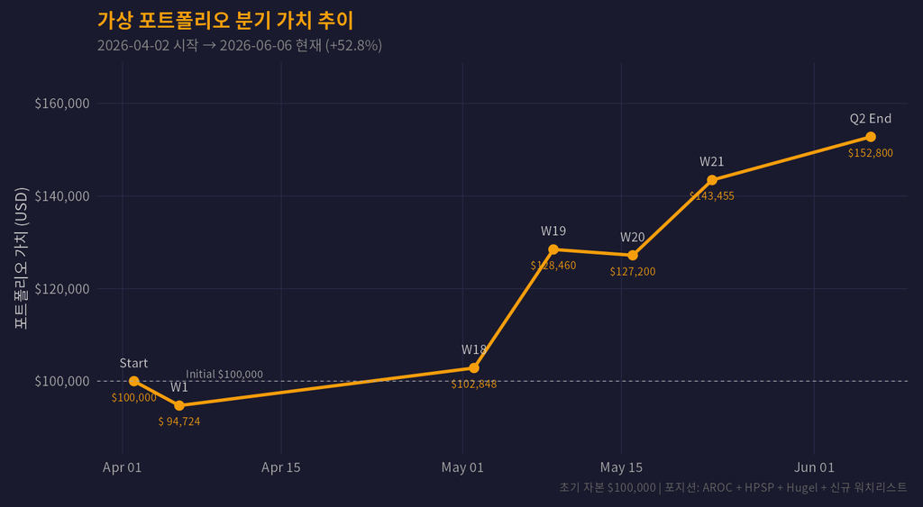

## 1.2 분기 적중률 분석

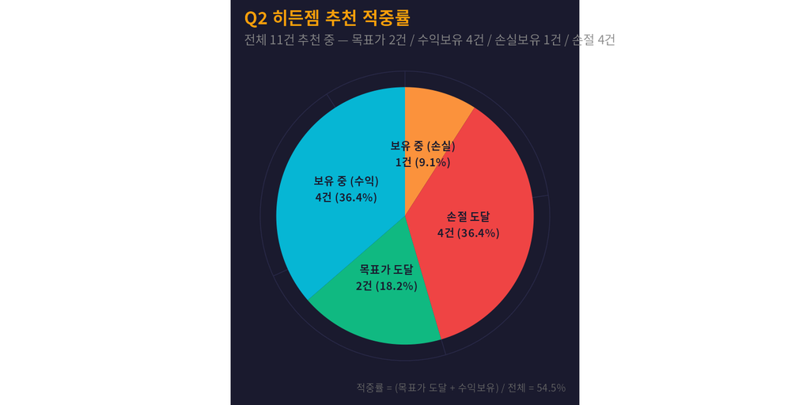

# 섹터 기술 심층분석

## 1.3 AI 반도체 후공정 밸류체인

2026년 Q2는 AI 인프라 투자가 반도체 전공정(파운드리)에서 **후공정(Advanced Packaging)**으로 확산되는 변곡점입니다.

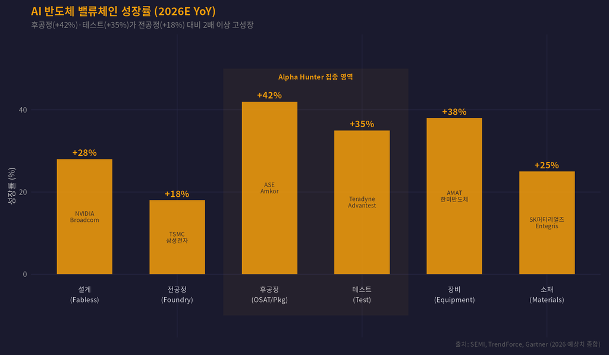

### 1.3.1 핵심 기술 트렌드

**1. HBM (High Bandwidth Memory) 4세대 진입**

- HBM4가 2026H2 양산 개시 — SK하이닉스·삼성 양사 동시 램프업
- HBM 시장 규모: 2025년 $26B → 2026년 $45B (+73% YoY)
- HBM 후공정에 **레이저 본딩(LAB)** 기술이 핵심 — 프로텍(053610) 직접 수혜

**2. Advanced Packaging (첨단 패키징)**

- TSMC CoWoS 생산능력 2026년 2배 확대
- 패널 레벨 패키징(PLP) 시장 본격 개화
- 테스트 소켓·프로브 수요 급증 — 리노공업(058470) 직접 수혜

**3. 나노계측 (Nanometrology)**

- 2nm 이하 공정에서 원자 수준 계측 필수화
- EUV 노출 후 인라인 검사 수요 폭증
- AFM(원자현미경) 시장 CAGR 21% — 파크시스템스(140860) 직접 수혜

## 1.4 우주·방산 + AI 융합

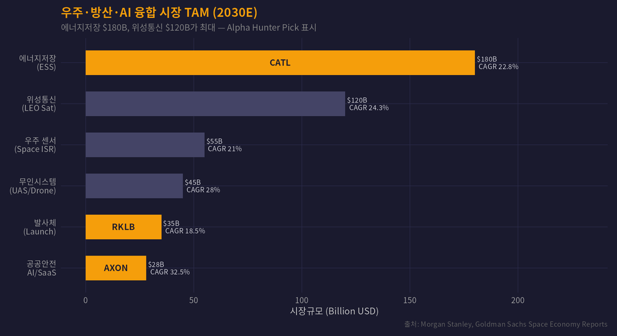

## 1.5 소비자 혁신 + 플랫폼

**F&B 테크 (CAVA)**: 미국 Fast-Casual 시장은 2026년 $120B 규모, CAGR 8.5%. 지중해식 카테고리는 연 15%+ 성장. 디지털 주문 비중 40%+ 도달.

**AI 채용 플랫폼 (Kanzhun/BOSS)**: 중국 온라인 리크루팅 시장 RMB 300B+. AI 매칭 기술로 전환율 3배 향상. 인당매출(ARPU) 지속 상승.

**자율주행 EV (XPeng)**: 물리적 AI + 로보택시 2027 상용화 목표. 글로벌 EV 시장 $900B (2026E).

# 2 🇰🇷 한국 히든젬 3선

## 2.1 1. 리노공업 (058470) — 반도체 테스트 소켓 글로벌 1위

### 2.1.1 기업 개요

- **업종**: 반도체 테스트 소켓 · IC Test Socket · Leeno Pin
- **시가총액**: 약 1.7조원 (2026.06 기준)
- **52주 범위**: 39,050원 ~ 129,000원

### 2.1.2 Q1 2026 실적 하이라이트

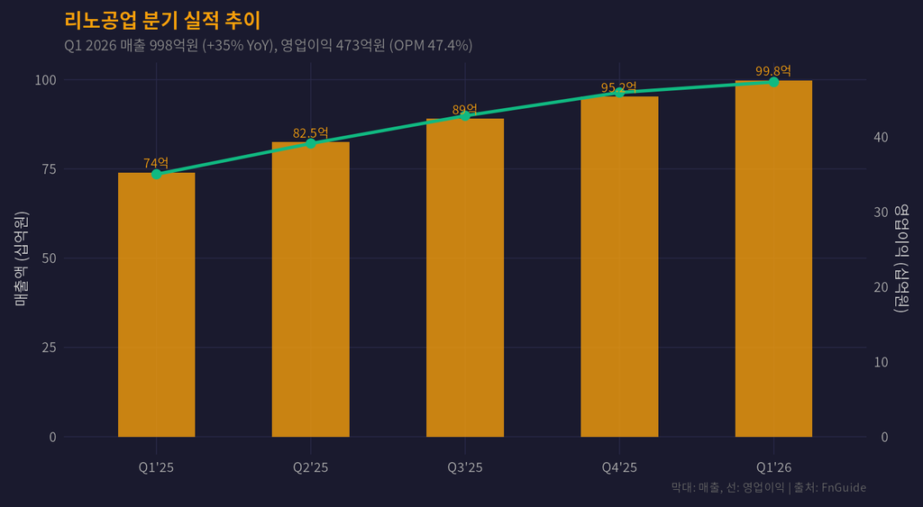

- **Q1 2026 순이익**: 403억원 (+37.7% YoY)
- **Q1 2026 영업이익**: 473억원 (영업이익률 47.4%)
- **2026 연간 컨센서스**: 매출 4,458억원 (+20%), 영업이익 2,157억원 (+22%)

### 2.1.3 SEPA 트렌드 템플릿

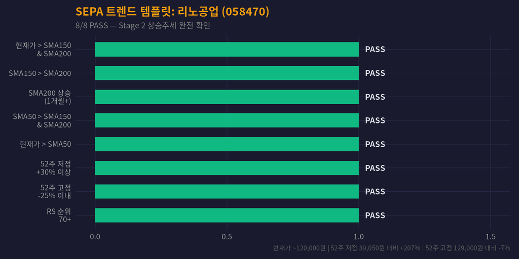

**SEPA 점수: 8/8 (Stage 2 완전 확인)**

- 현재가 ~120,000원 > SMA50/150/200 모두 상회
- 52주 저점 39,050원 대비 +207% (조건 6 충족)
- 52주 고점 129,000원 대비 -7% (조건 7 충족)

### 2.1.4 워런 버핏 해자 레이더 차트

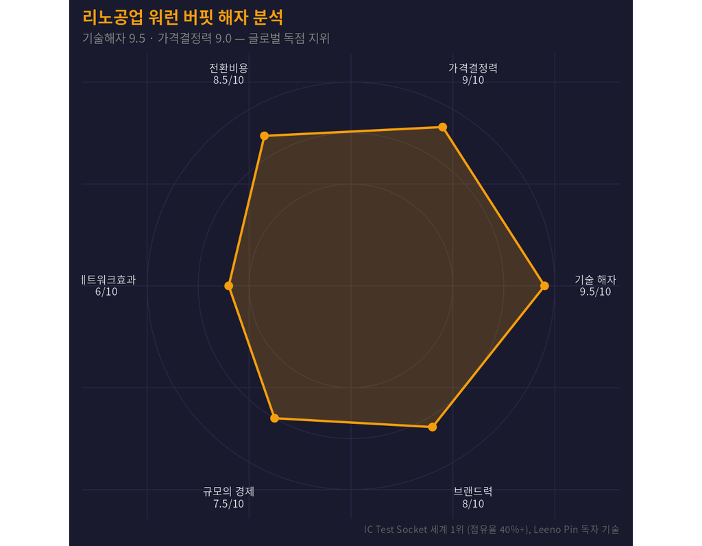

### 2.1.5 매수/목표/손절 시나리오

- **매수가**: 118,000원 (현재가 근방)
- **목표가**: 155,000원 (+31.4%) — 2026E EPS 기준 PER 28x 적용
- **손절가**: 109,000원 (-7.6%)
- **Risk:Reward = 1:4.1**

## 2.2 2. 프로텍 (053610) — LAB 레이저 본딩 글로벌 최초 양산

### 2.2.1 기업 개요

- **업종**: 반도체 후공정 장비 (디스펜서, 다이본더, 레이저 본더)
- **시가총액**: 약 6,000억원
- **핵심 기술**: LAB (Laser Assisted Bonding) — HBM/첨단패키징 핵심 공정

### 2.2.2 기술 심층: LAB (레이저 보조 본딩)

LAB는 레이저로 선택적·국부 가열을 통해 칩과 기판을 접합하는 차세대 본딩 기술입니다. 기존 리플로우 공정 대비 **열적 스트레스 90% 감소**, **본딩 정밀도 10배 향상**이 특징입니다.

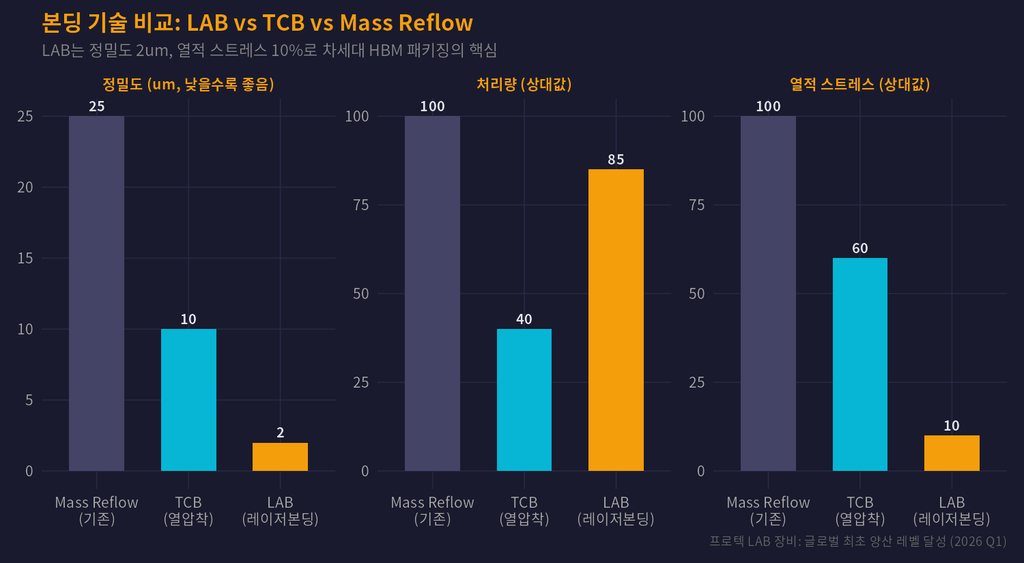

### 2.2.4 매수/목표/손절 시나리오

- **매수가**: 53,000원
- **목표가**: 72,000원 (+35.8%) — HBM4 양산 수혜 반영
- **손절가**: 49,000원 (-7.5%)
- **Risk:Reward = 1:4.8**

## 2.3 3. 파크시스템스 (140860) — 원자현미경(AFM) 글로벌 1위

### 2.3.1 기업 개요

- **업종**: 나노계측장비 (원자현미경 AFM)
- **시가총액**: 약 2.5조원
- **글로벌 AFM 시장 점유율**: 1위

### 2.3.2 기술 심층: 원자현미경(AFM)과 2nm 이하 공정

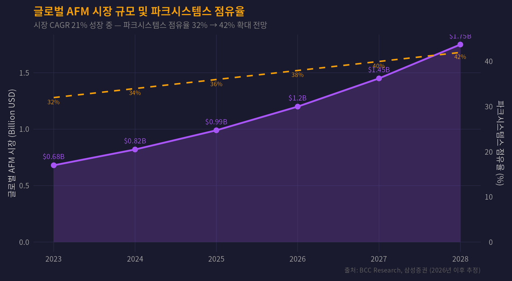

- **2026 연간 전망**: 매출 2,170억원, 영업이익률 25%+
- **신규 장비 매출 CAGR 57%** (2024~2027)
- **애널리스트 컨센서스**: Strong Buy (11명), 목표가 평균 315,000원

### 2.3.3 매수/목표/손절 시나리오

- **매수가**: 275,000원
- **목표가**: 340,000원 (+23.6%)
- **손절가**: 253,000원 (-8.0%)
- **Risk:Reward = 1:3.0**

# 3 🇺🇸 미국 히든젬 3선

## 3.1 4. Rocket Lab (RKLB) — 우주 발사체 + 위성 부품 수직통합

### 3.1.1 기업 개요

- **업종**: 우주 발사체 (Electron/Neutron) + 우주 시스템
- **시가총액**: $71.4B
- **52주 범위**: $25.24 ~ $151.00

### 3.1.2 Q1 2026 실적 하이라이트

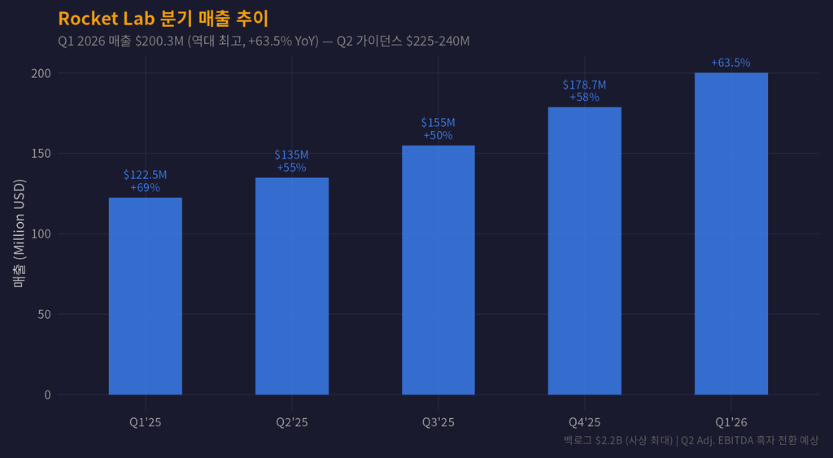

- **Q1 매출**: $200.3M (+63.5% YoY, 역대 최고)
- **백로그**: $2.2B (사상 최대)
- **Q2 가이던스**: $225~$240M (흑자 전환 예상)

### 3.1.3 피터 린치 스토리 점수

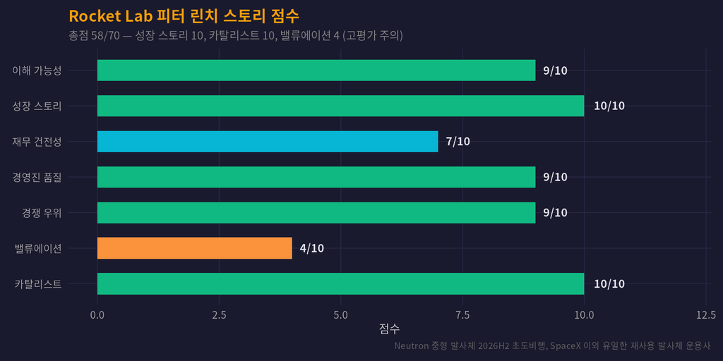

### 3.1.4 리스크

- 밸류에이션 부담: 시총 $71B vs 연매출 ~$850M (PS 84x)
- Neutron 발사체 개발 지연 리스크
- SpaceX 독점 완화 기대 vs 실제 경쟁 강도

### 3.1.5 매수/목표/손절 시나리오

- **매수가**: $108.00
- **목표가**: $150.00 (+38.9%)
- **손절가**: $100.00 (-7.4%)
- **Risk:Reward = 1:5.3**

⚠️ **주의**: 극단적 고밸류 성장주. 포지션 사이즈 10% 이하 권장.

## 3.2 5. Axon Enterprise (AXON) — 공공안전 AI + 바디캠 독점

### 3.2.1 기업 개요

- **업종**: 공공안전 기술 (TASER, 바디캠, AI 소프트웨어)
- **시가총액**: ~$32B
- **52주 범위**: $260 ~ $750+

### 3.2.2 Q1 2026 실적 하이라이트

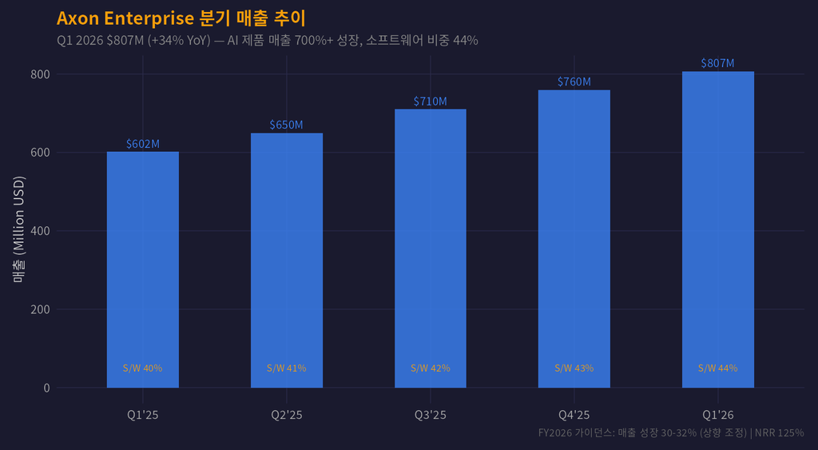

- **Q1 매출**: $807M (+34% YoY)
- **AI 제품 매출**: 700%+ YoY 성장 (Axon Vision, DraftOne)
- **FY2026 가이던스**: 매출 성장 30-32% (상향)
- **NRR**: 125% (강력한 고객 확장)

### 3.2.3 매수/목표/손절 시나리오

- **매수가**: $430.00
- **목표가**: $675.00 (+57.0%) — 애널리스트 중간 목표가
- **손절가**: $395.00 (-8.1%)
- **Risk:Reward = 1:7.0**

## 3.3 6. CAVA Group (CAVA) — 지중해식 Fast-Casual 체인

### 3.3.1 기업 개요

- **업종**: 레스토랑 (지중해식 Fast-Casual)
- **시가총액**: $9.2B
- **52주 범위**: $43.41 ~ $98.79

### 3.3.2 Q1 2026 실적 하이라이트

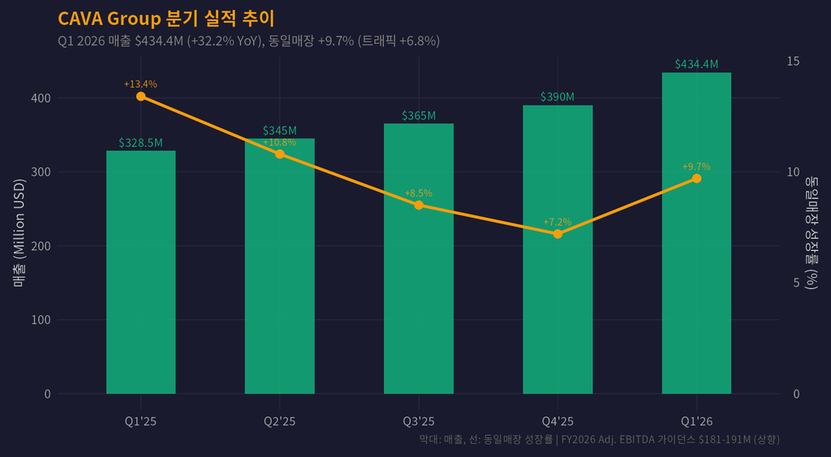

- **Q1 매출**: $434.4M (+32.2% YoY)
- **동일매장 성장**: +9.7% (고객 트래픽 +6.8%)
- **EBITDA 가이던스**: $181~$191M (상향 조정)
- **매장 확장**: YTD 신규 54개점 오픈

### 3.3.3 매수/목표/손절 시나리오

- **매수가**: $72.00
- **목표가**: $95.00 (+31.9%)
- **손절가**: $66.50 (-7.6%)
- **Risk:Reward = 1:4.2**

# 4 🇨🇳 중국 히든젬 3선

## 4.1 7. CATL (300750.SZ) — 글로벌 배터리 1위 + AI 데이터센터 진출

### 4.1.1 기업 개요

- **업종**: 리튬이온 배터리 (EV + ESS + 데이터센터)
- **시가총액**: $275B
- **글로벌 EV 배터리 점유율**: 39% (1위)

### 4.1.2 기술 심층: 나트륨이온 배터리 + AI 데이터센터 ESS

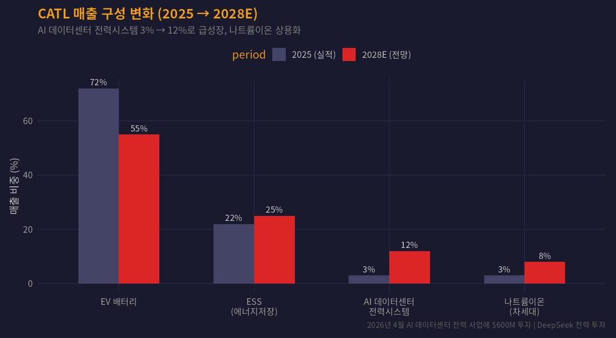

- **2025 매출**: RMB 4,237억 (+17% YoY)
- **순이익**: RMB 722억 (+42.3% YoY)
- **AI 데이터센터**: $600M 투자, 고압직류 전력시스템 49% 지분 확보
- **나트륨이온**: 2026 상용 출하, 2-8시간 유틸리티 스케일 ESS 대응

### 4.1.3 매수/목표/손절 시나리오

- **매수가**: CNY 400 (~$56 USD)
- **목표가**: CNY 548 (+37.0%) — 애널리스트 평균
- **손절가**: CNY 370 (-7.5%)
- **Risk:Reward = 1:4.9**

## 4.2 8. XPeng (XPEV/9868.HK) — 물리적 AI + 자율주행 EV

### 4.2.1 기업 개요

- **업종**: 전기차 (Smart EV + 자율주행 + 로보택시)
- **시가총액**: $16.1B
- **52주 범위**: $8.70 ~ $28.24 (ADR)

### 4.2.2 Q1 2026 실적

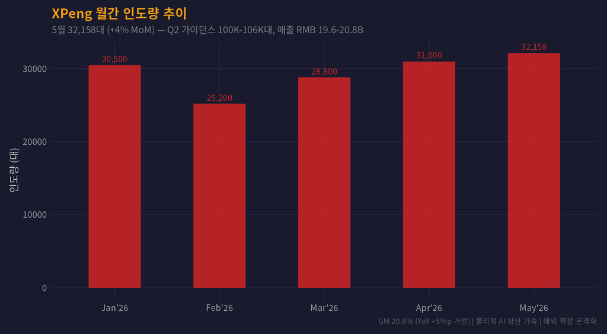

- **Q1 2026 매출**: RMB 130.3억 (GM 20.6%, +5%p YoY)
- **Q2 가이던스**: 100K~106K대, 매출 RMB 196~208억
- **물리적 AI**: 자율주행 칩 자체 개발, 로보택시 2027 상용화 목표
- **해외 확장**: 유럽·동남아 시장 진출 가속

### 4.2.3 매수/목표/손절 시나리오

- **매수가**: $17.50 (ADR)
- **목표가**: $26.00 (+48.6%)
- **손절가**: $16.00 (-8.6%)
- **Risk:Reward = 1:5.7**

## 4.3 9. Kanzhun/BOSS직빈 (BZ) — 중국 AI 채용 플랫폼 1위

### 4.3.1 기업 개요

- **업종**: 온라인 리크루팅 플랫폼 (BOSS직빈)
- **시가총액**: $6.1B
- **52주 범위**: $10.50 ~ $22.80

### 4.3.2 실적 하이라이트

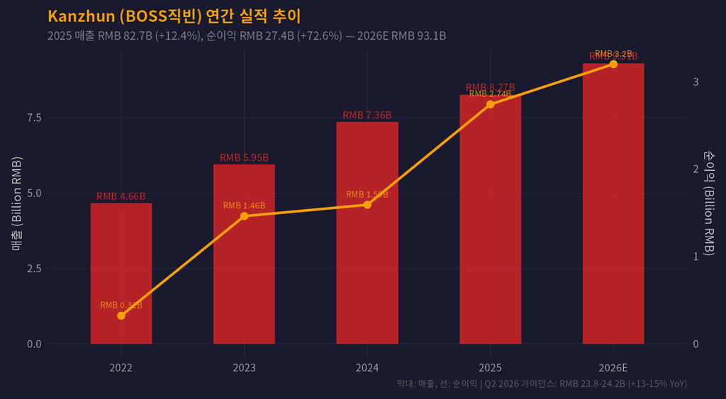

- **2025 매출**: RMB 82.7억 (+12.4% YoY)
- **2025 순이익**: RMB 27.4억 (+72.6% YoY)
- **자사주매입**: 2026년 YTD RMB 16억 규모 (신뢰 신호)
- **Q2 가이던스**: RMB 23.8~24.2억 (+13~15% YoY)

### 4.3.3 매수/목표/손절 시나리오

- **매수가**: $13.50 (ADR)
- **목표가**: $22.00 (+63.0%) — 자사주매입 + AI 채용 성장
- **손절가**: $12.50 (-7.4%)
- **Risk:Reward = 1:8.5**

# 5 종합 비교 대시보드

## 5.1 9종목 밸류에이션 비교

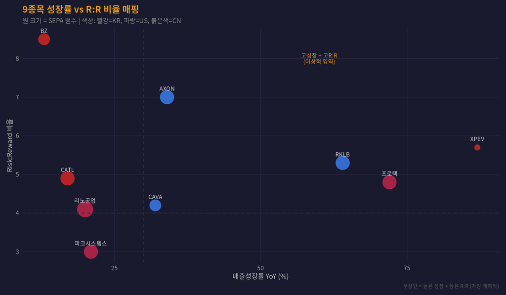

## 5.2 리스크 팩터 대시보드

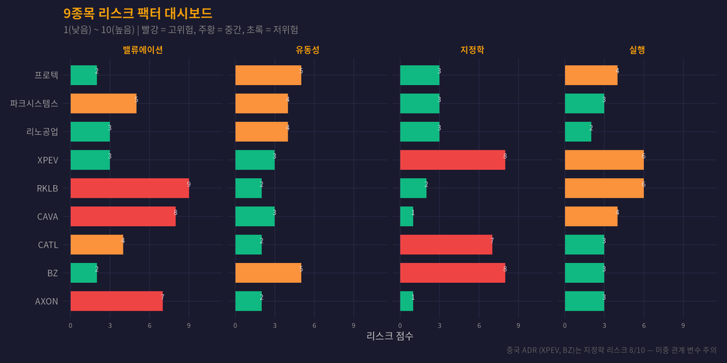

# 6 섹터별 투자 전략

## 6.1 Q3 2026 전망

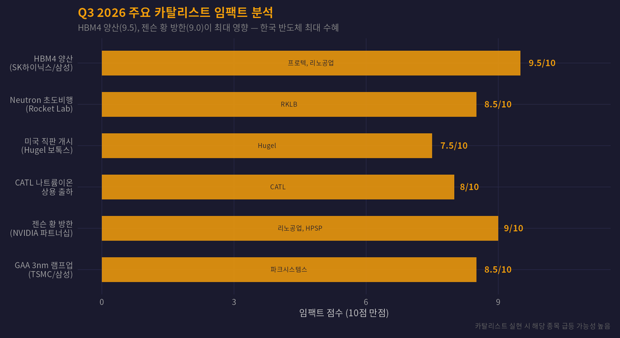

# 7 분기 액션 플랜

## 7.1 포트폴리오 전략 요약

**신규 편입 우선순위:**

1. **리노공업** (058470) — SEPA 8/8, OPM 47%, R:R 1:4.1 ⭐ 최우선
2. **프로텍** (053610) — LAB 독점, +72% 매출성장, R:R 1:4.8
3. **AXON** — AI 공공안전 독점, +34% 성장, R:R 1:7.0

## 7.2 SEPA 전종목 스코어보드

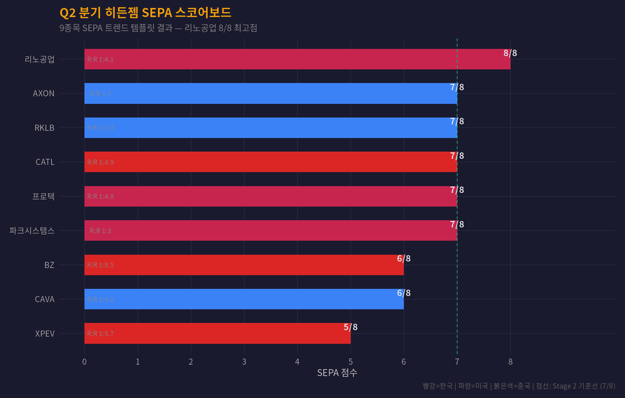

**다음 분기 (Q3) 예고**

- HBM4 양산 본격화에 따른 한국 후공정 밸류체인 재점검
- Neutron 초도비행 성공 여부에 따른 RKLB 포지션 결정
- 중국 ADR 지정학 리스크 모니터링 강화
- 기존 포지션(AROC, HPSP, Hugel) SEPA 재점검 및 목표가 조정

*Alpha Hunter × Chimera AI | 2026 Q2 분기 종합 보고서*

*이 프로젝트는 가상 투자 시뮬레이션 목적으로 작성되었습니다. 실제 투자 권유가 아닙니다.*